# Lead-Lag ONI terhadap SDCI Indonesia (2000-2025)

Analisis statistik dengan R - Team LogLoss, UNNES

## 1. Data dan anomali SDCI

Data bulanan 2000-01 sampai 2025-12 (312 baris). Anomali SDCI adalah SDCI dikurangi rata-rata bulanannya (klimatologi), supaya pola musiman tidak mengaburkan hubungan dengan ONI.

```r
# Path relatif terhadap folder R/ (lokasi file ini). Di Kaggle: ganti path ke data_master.csv.
f <- "../data/master_dataset_godzilla_elnino_2000_2025.csv"
d <- read.csv(f); d$date <- as.Date(d$date_key); d$m <- factor(format(d$date, "%m"))
reg <- c("Indo", "Sumatera", "Jawa", "Kalimantan", "Sulawesi", "NusaTenggara", "Maluku", "Papua")
for (r in reg) { v <- paste0("SDCI_", r); d[[paste0("A_", r)]] <- d[[v]] - ave(d[[v]], d$m) }
summary(d[, c("SDCI_Indo", "ONI", "sst_anomaly")])
```

```
##    SDCI_Indo            ONI              sst_anomaly
##  Min.   :0.01349   Min.   :-1.3991575   Min.   :-1.4709307
##  1st Qu.:0.55844   1st Qu.:-0.5500420   1st Qu.:-0.5535272
##  Median :0.63461   Median :-0.1261673   Median :-0.0845050
##  Mean   :0.62039   Mean   : 0.0006652   Mean   : 0.0003225
##  3rd Qu.:0.69914   3rd Qu.: 0.4611753   3rd Qu.: 0.4676061
##  Max.   :0.86505   Max.   : 2.6205400   Max.   : 2.7596076
```

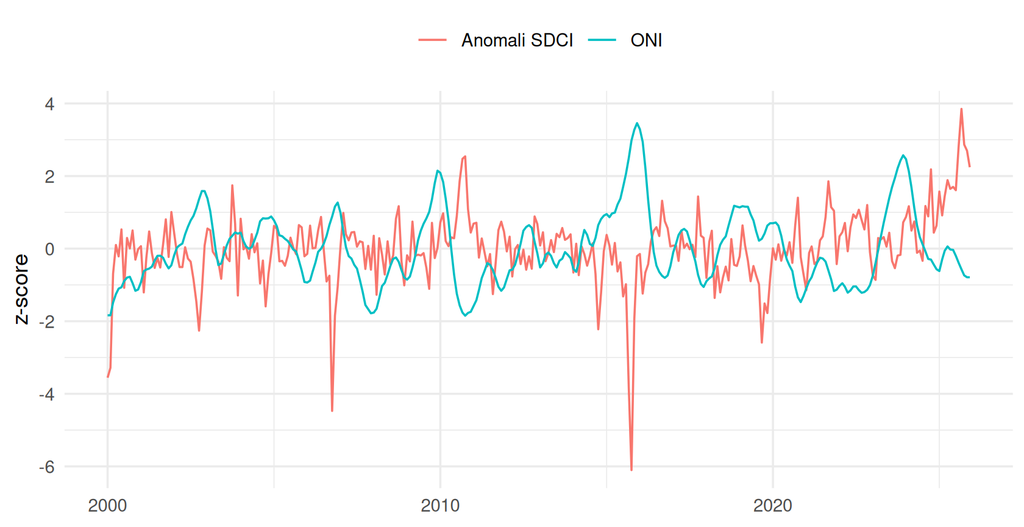

Anomali SDCI nasional dan ONI (z-score).

```r
ggplot(d, aes(date)) +
  geom_line(aes(y = scale(A_Indo)[, 1], colour = "Anomali SDCI")) +
  geom_line(aes(y = scale(ONI)[, 1], colour = "ONI")) +
  labs(x = NULL, y = "z-score", colour = NULL) + theme_minimal(base_size = 11) + theme(legend.position = "top")
```

## 2. Korelasi silang ONI(t) dan anomali SDCI(t+h)

```r
cc <- do.call(rbind, lapply(reg, function(r) data.frame(wilayah = r, h = 0:12,
  r = sapply(0:12, function(h) cor(head(d$ONI, nrow(d) - h), tail(d[[paste0("A_", r)]], nrow(d) - h))))))
cc %>% group_by(wilayah) %>% slice_min(r, n = 1) %>% ungroup() %>% as.data.frame()
```

| wilayah | h | r |
| --- | --- | --- |
| Indo | 0 | -0.2913294 |
| Jawa | 0 | -0.3331687 |
| Kalimantan | 0 | -0.1922606 |
| Maluku | 0 | -0.1751270 |
| NusaTenggara | 0 | -0.3362834 |
| Papua | 0 | -0.1383787 |
| Sulawesi | 0 | -0.2609687 |
| Sumatera | 0 | -0.2269237 |

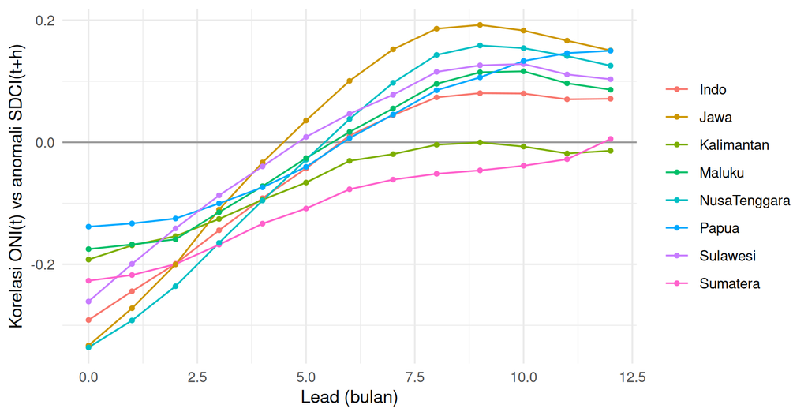

Korelasi silang per wilayah, lead 0-12 bulan.

```r
ggplot(cc, aes(h, r, colour = wilayah)) + geom_hline(yintercept = 0, colour = "grey60") +
  geom_line() + geom_point(size = 1) +
  labs(x = "Lead (bulan)", y = "Korelasi ONI(t) vs anomali SDCI(t+h)", colour = NULL) + theme_minimal(base_size = 11)
```

Korelasi terkuat selalu di lead 0 dan bernilai negatif (-0,14 sampai -0,34): pengaruh ONI cepat melemah, bukan tertunda.

## 3. Regresi lead dengan galat Newey-West

```r
reg_h <- do.call(rbind, lapply(0:9, function(h) {
  y <- tail(d$A_Indo, nrow(d) - h); x <- head(d$ONI, nrow(d) - h); m <- lm(y ~ x)
  ct <- coeftest(m, vcov = NeweyWest(m, lag = 12, prewhite = FALSE))
  data.frame(h = h, beta = ct[2, 1], se = ct[2, 2], p = ct[2, 4], R2 = summary(m)$r.squared)
}))
round(reg_h, 4)
```

| h | beta | se | p | R2 |
| --- | --- | --- | --- | --- |
| 0 | -0.0282 | 0.0122 | 0.0212 | 0.0849 |
| 1 | -0.0232 | 0.0108 | 0.0324 | 0.0596 |
| 2 | -0.0186 | 0.0096 | 0.0527 | 0.0397 |
| 3 | -0.0135 | 0.0087 | 0.1214 | 0.0208 |
| 4 | -0.0086 | 0.0082 | 0.2975 | 0.0084 |
| 5 | -0.0040 | 0.0082 | 0.6234 | 0.0018 |
| 6 | 0.0010 | 0.0084 | 0.9024 | 0.0001 |
| 7 | 0.0041 | 0.0088 | 0.6402 | 0.0020 |
| 8 | 0.0069 | 0.0092 | 0.4569 | 0.0054 |
| 9 | 0.0075 | 0.0094 | 0.4250 | 0.0065 |

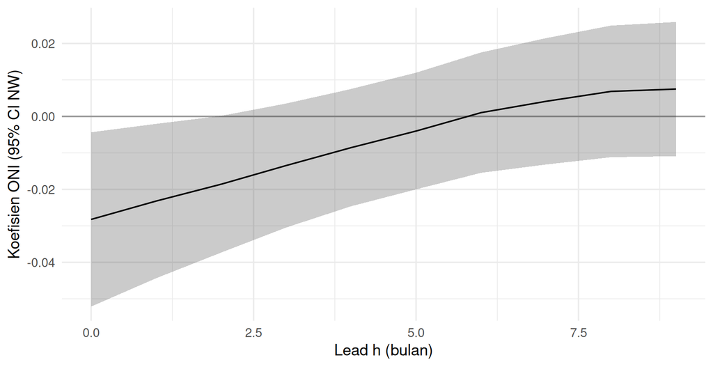

Koefisien ONI pada anomali SDCI(t+h), CI 95% Newey-West.

```r
ggplot(reg_h, aes(h, beta)) + geom_hline(yintercept = 0, colour = "grey60") +
  geom_ribbon(aes(ymin = beta - 1.96 * se, ymax = beta + 1.96 * se), alpha = .25) + geom_line() +
  labs(x = "Lead h (bulan)", y = "Koefisien ONI (95% CI NW)") + theme_minimal(base_size = 11)
```

## 4. Uji kausalitas Granger (ONI ke anomali SDCI)

```r
sapply(c(3, 6, 9), function(k) grangertest(A_Indo ~ ONI, order = k, data = d)$`Pr(>F)`[2]) |>
  setNames(paste("order", c(3, 6, 9))) |> round(4)
```

```
## order 3 order 6 order 9
##  0.0912  0.1537  0.0514
```

## 5. Peragaan kebocoran target (bukan model)

SDCI dibangun dari NDVI, LST, dan curah hujan. Regresi linier dari ketiganya pada bulan yang sama memberi R² = 1, sehingga variabel itu tidak boleh menjadi prediktor.

```r
s <- floor(nrow(d) * .8); tr <- d[1:s, ]; te <- d[(s + 1):nrow(d), ]
r2 <- function(f) { m <- lm(f, tr); p <- predict(m, te); 1 - sum((te$SDCI_Indo - p)^2) / sum((te$SDCI_Indo - mean(te$SDCI_Indo))^2) }
c(komponen_SDCI = r2(SDCI_Indo ~ ndvi_Indo + lst_Indo + precip_Indo),
  ONI_sst_bulan_sama = r2(SDCI_Indo ~ ONI + sst_anomaly)) |> round(4)
```

```
##      komponen_SDCI ONI_sst_bulan_sama
##              1.000             -0.373
```

## 6. Model tanpa kebocoran (lead 3 bulan)

Fitur ENSO digeser H = 3 bulan ditambah musiman bulan, OLS, split 80/20 pada sampel yang sama dengan notebook Python (297 bulan, test 60 bulan).

```r
H <- 3; mk <- function(v) c(rep(NA, H), head(v, length(v) - H))
d$ONI_H <- mk(d$ONI); d$sst_H <- mk(d$sst_anomaly); d$mom_H <- mk(c(NA, diff(d$ONI)))
dd <- d[complete.cases(d[, c("ONI_H", "sst_H", "mom_H")]) & d$date >= as.Date("2001-04-01"), ]
s2 <- floor(nrow(dd) * .8); tr2 <- dd[1:s2, ]; te2 <- dd[(s2 + 1):nrow(dd), ]
r2b <- function(f) { m <- lm(f, tr2); p <- predict(m, te2); 1 - sum((te2$SDCI_Indo - p)^2) / sum((te2$SDCI_Indo - mean(te2$SDCI_Indo))^2) }
c(n = nrow(dd), ENSO_lag3_musiman = r2b(SDCI_Indo ~ ONI_H + sst_H + mom_H + m), Klimatologi = r2b(SDCI_Indo ~ m)) |> round(4)
```

```
##                 n ENSO_lag3_musiman       Klimatologi
##          297.0000           -0.0554           -0.0505
```

Kedua nilai R² mendekati nol dan model ENSO tidak lebih baik dari klimatologi.

## 7. Evaluasi out-of-sample (jendela meluas, test 2021-2025)

Setiap bulan uji diprediksi hanya dengan data yang sudah tersedia (pasangan ONI(j) dan SDCI(j+h) dengan j+h < t), dibandingkan dengan klimatologi bulanan.

```r
fc <- do.call(rbind, lapply(c(1, 3, 6, 9), function(h) {
  n <- nrow(d); idx <- (s + 1):(n - h)
  e <- sapply(idx, function(t) {
    j <- 1:(t - 1 - h); dj <- data.frame(y = d$SDCI_Indo[j + h], oni = d$ONI[j], m = d$m[j + h])
    mm <- lm(y ~ oni + m, dj); mc <- lm(y ~ m, dj)
    nd <- data.frame(oni = d$ONI[t - h], m = d$m[t])
    c(d$SDCI_Indo[t] - predict(mm, nd), d$SDCI_Indo[t] - predict(mc, nd))
  })
  data.frame(h = h, RMSE_ONI = sqrt(mean(e[1, ]^2)), RMSE_klim = sqrt(mean(e[2, ]^2)),
             skill = 1 - mean(e[1, ]^2) / mean(e[2, ]^2), n = ncol(e))
}))
round(fc, 4)
```

| h | RMSE_ONI | RMSE_klim | skill | n |
| --- | --- | --- | --- | --- |
| 1 | 0.0933 | 0.0933 | -0.0017 | 62 |
| 3 | 0.0869 | 0.0862 | -0.0173 | 60 |
| 6 | 0.0726 | 0.0724 | -0.0038 | 57 |
| 9 | 0.0675 | 0.0674 | -0.0015 | 54 |

`skill` negatif berarti model ONI tidak mengalahkan klimatologi pada semua lead.

## 8. Heterogenitas wilayah

```r
het <- do.call(rbind, lapply(reg, function(r) {
  best <- cc$h[cc$wilayah == r][which.min(cc$r[cc$wilayah == r])]
  y <- tail(d[[paste0("A_", r)]], nrow(d) - best); x <- head(d$ONI, nrow(d) - best); m <- lm(y ~ x)
  ct <- coeftest(m, vcov = NeweyWest(m, lag = 12, prewhite = FALSE))
  data.frame(wilayah = r, h = best, beta = ct[2, 1], p = ct[2, 4], R2 = summary(m)$r.squared)
}))
het %>% mutate(across(where(is.numeric), ~ round(.x, 4)))
```

| wilayah | h | beta | p | R2 |
| --- | --- | --- | --- | --- |
| Indo | 0 | -0.0282 | 0.0212 | 0.0849 |
| Sumatera | 0 | -0.0207 | 0.0496 | 0.0515 |
| Jawa | 0 | -0.0354 | 0.0005 | 0.1110 |
| Kalimantan | 0 | -0.0191 | 0.1537 | 0.0370 |
| Sulawesi | 0 | -0.0240 | 0.0095 | 0.0681 |
| NusaTenggara | 0 | -0.0383 | 0.0010 | 0.1131 |
| Maluku | 0 | -0.0171 | 0.1379 | 0.0307 |
| Papua | 0 | -0.0111 | 0.2058 | 0.0191 |

Pengaruh ONI terbesar di Nusa Tenggara dan Jawa (koefisien -0,038 dan -0,035, p < 0,01); Papua, Maluku, dan Kalimantan tidak signifikan.